# pop2

[figure not shown]

**GENÉTICA DE POPULAÇÕES II**

Prof. Saulo Chaves

ESALQ / USP - Departamento de Genética

LGN 215 - Genética

## Anteriormente em LGN0215

Uma população é um conjunto de indivíduos que ocupam o mesmo local, ao mesmo tempo, capazes de se intercruzarem. Se **panmítica**, todos os indivíduos da população realizam acasalamento ao acaso e são capazes de transmitir alelos para as próximas gerações.

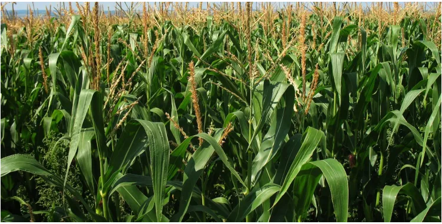

[FoodForAfrika](https://foodforafrika.com/2022/01/25/how-to-plant-maize-in-nigeria/)

## Anteriormente em LGN0215

| Genótipo | Nº de indivíduos | Freq. genotípica |
| --- | --- | --- |
| $AA$ $Aa$ $aa$ | $n_{AA}$ $n_{Aa}$ $n_{aa}$ | $D = \frac{n_{AA}}{N}$ $H = \frac{n_{Aa}}{N}$ $R = \frac{n_{aa}}{N}$ |
|  | $N$ | $D + H + R = 1$ |

## Anteriormente em LGN0215

| Genótipo | Nº de indivíduos | Nº de alelos $A$ | Nº de alelos $a$ | Total de alelos |
| --- | --- | --- | --- | --- |
| $AA$ $Aa$ $aa$ | $n_{AA}$ $n_{Aa}$ $n_{aa}$ | $2\times n_{AA}$ $n_{Aa}$ $0$ | $0$ $n_{Aa}$ $2 \times n_{aa}$ | $2\times n_{AA}$ $2 \times n_{Aa}$ $2 \times n_{aa}$ |
|  | $N$ |  |  | $2N$ |

$$f(A) = p = \begin{cases}
\frac{2n_{AA} + n_{Aa}}{2N} \\
\frac{n_{AA} + \frac{1}{2}n_{Aa}}{N} \\
D + \frac{1}{2} H
\end{cases}$$

$$f(a) = q = \begin{cases}
\frac{2n_{aa} + n_{Aa}}{2N} \\
\frac{n_{aa} + \frac{1}{2}n_{Aa}}{N} \\
R + \frac{1}{2} H
\end{cases}$$

## Anteriormente em LGN0215

O equilíbrio de Hardy-Weinberg é um modelo matemático que descreve a constância das frequências alélicas e genotípicas através de gerações de acasalamento ao acaso, sob determinadas pressuposições.

[figure not shown]

## Conteúdo de hoje

1. Endogamia
   - Depressão endogâmica
   - Coeficiente de endogamia $\left(F\right)$
2. Equilíbrio de Wright
3. Índice de fixação
   - Taxa aparente de autofecundação
   - Taxa aparente de fecundação cruzada

# Endogamia

## Endogamia

- Acasalamento entre indivíduos aparentados
- União de cópias de um mesmo alelo ancestral
- Cruzamento entre aparentados (irmãos, primos, descendentes, etc.)

**Coeficiente de endogamia**

Probabilidade de dois alelos de um mesmo loco tomados ao acaso sejam idênticos por descendência

## Endogamia

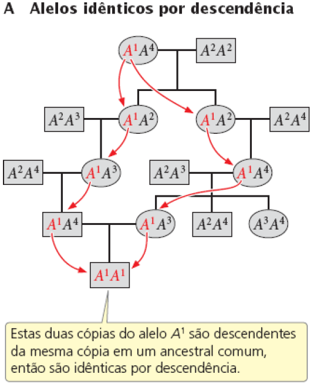

Pierce (2016)

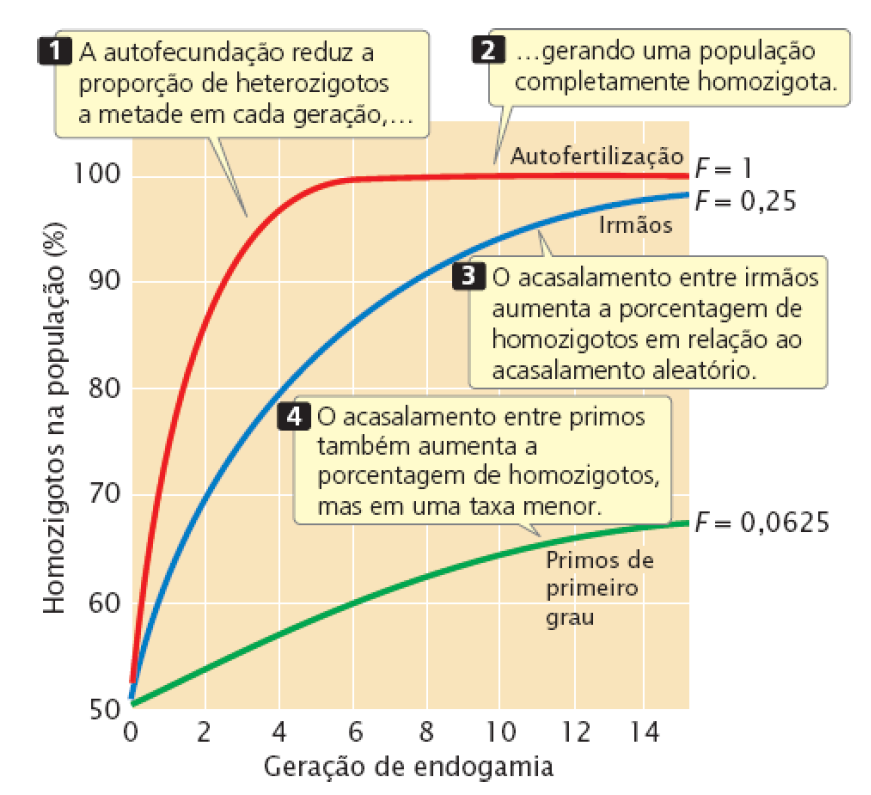

Pierce (2016)

- A endogamia reduz a taxa de heterozigotos na população
- Relação com a diversidade genética

## Endogamia em plantas

- Melhoramento

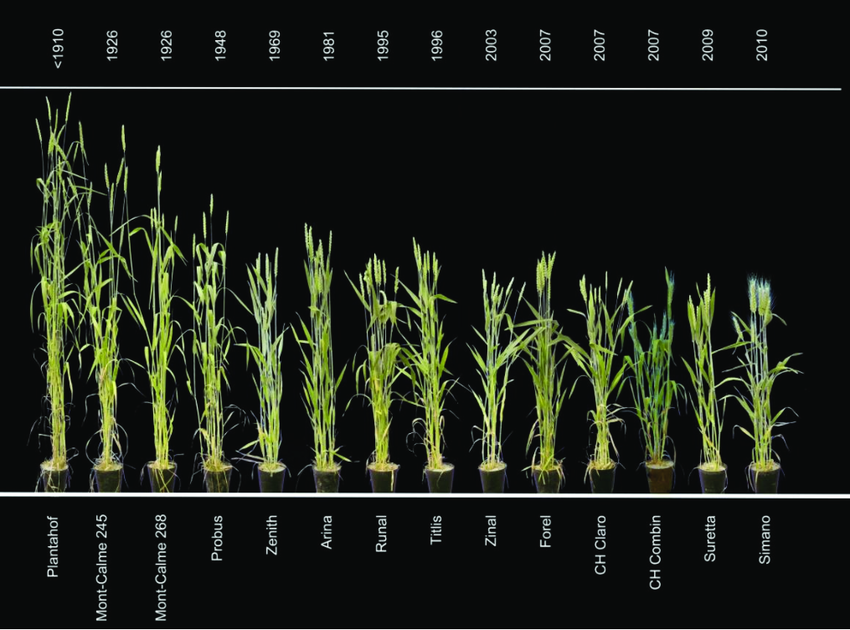

[Friedli et al. (2019)](https://link.springer.com/article/10.1007/s10681-019-2404-7)

- Depressão endogâmica

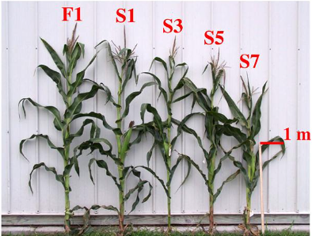

[Yao et al. (2020)](https://www.frontiersin.org/journals/genetics/articles/10.3389/fgene.2020.564928/full)

## Endogamia em plantas

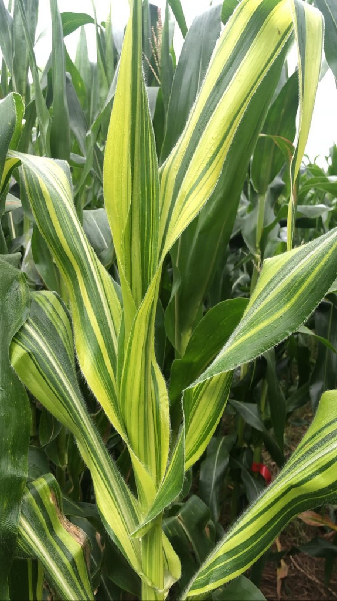

Alice Santana

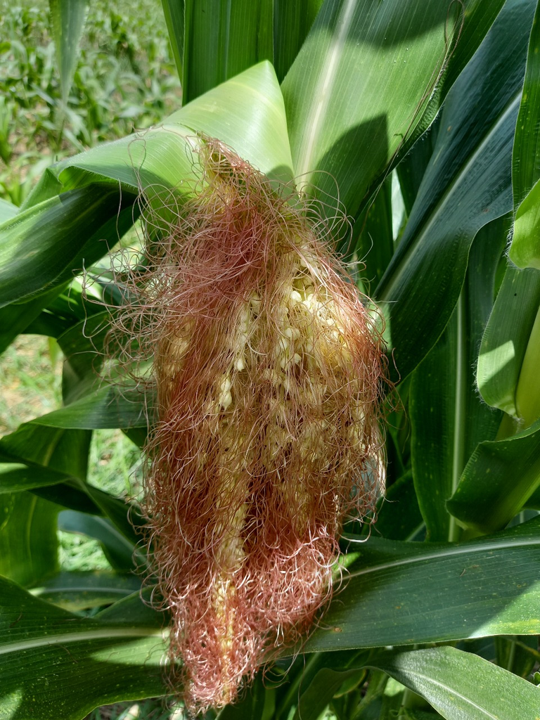

Alice Santana

## Endogamia em humanos

[figure not shown]

[Museu Nacional de Belas Artes](http://www.bellasartes.gob.ar/coleccion/obra/6816)

- Prognatismo mandibular ou mandíbula de Habsburgo:
  - A mandíbula é mais protuberante em relação à maxila
  - Causado por um gene autosomal, com penetrância incompleta
  - Potencializado por casamento entre parentes

## Endogamia em humanos

[figure not shown]

[the Palaces of Europe](https://www.palaces-of-europe.com/spanish-habsburg-family-tree.html#gallery[pageGallery]/0/)

- Característica marcante de indivíduos da linhagem espanhola do clã Habsburgo
- A carga genética foi uma das responsáveis pela derrocada do clã
  - Problemas mentais e de fertilidade de Charles II

## Endogamia em humanos

[figure not shown]

[Reddit/UsefulCharts](https://www.reddit.com/r/UsefulCharts/comments/1jh616v/extended_family_tree_and_timeline_of_the_habsburg/)

## Endogamia em humanos

Imperador Pedro II, Filho de Maria Leopoldina, da casa de Habsburgo-Lorena

[figure not shown]

[Museu Histórico Nacional](https://commons.wikimedia.org/wiki/File:Pedro_II_%2820%29,_da_cole%C3%A7%C3%A3o_Museu_Hist%C3%B3rico_Nacional.jpg)

## Endogamia em humanos

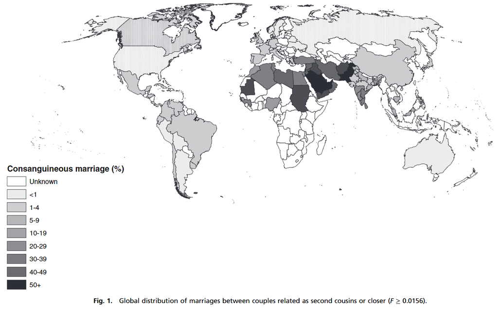

[Bittles & Black (2010)](https://www.pnas.org/doi/epdf/10.1073/pnas.0906079106)

## Endogamia em humanos

**Família Whittaker**: Gerações de consanguinidade

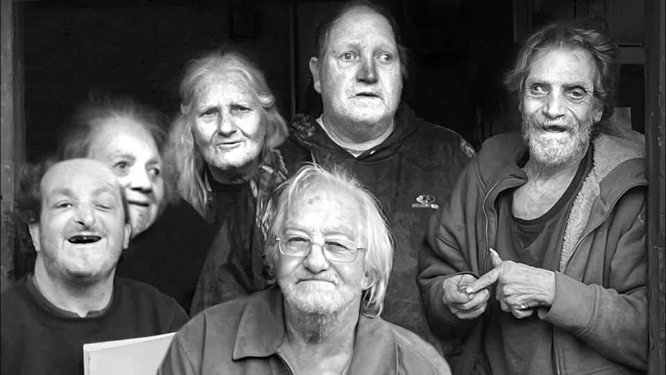

[Soft White Underbelly](https://www.youtube.com/watch?v=WnzMPF6vFJk)

## Endogamia em humanos

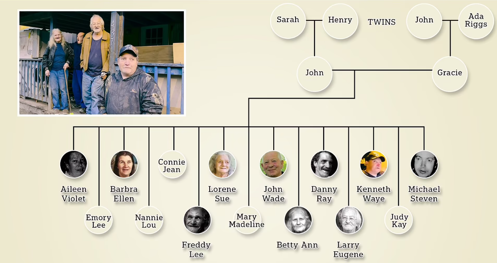

[Daily Mail](https://www.dailymail.co.uk/news/article-11933679/Americas-inbred-family-started-IDENTICAL-TWIN-brothers-kids-married-other.html)

## Endogamia em humanos

[figure not shown]

[Netflix](https://territorystudio.com/project/the-man-with-1000-kids/)

[figure not shown]

[Netflix](https://www.netflix.com/tudum/articles/our-father-documentary-trailer)

## Endogamia em humanos

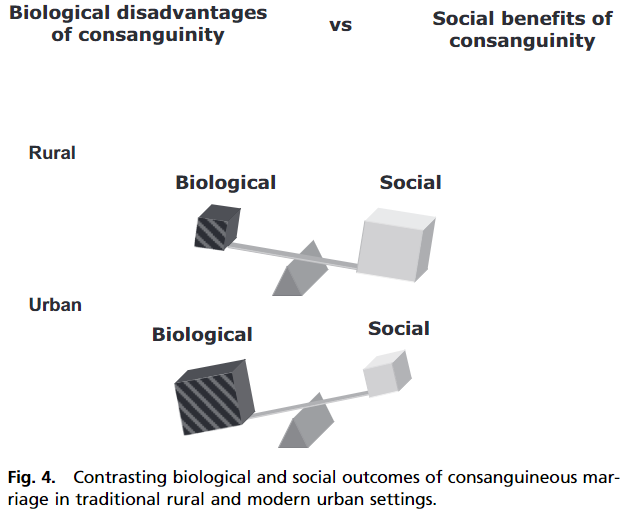

[Bittles & Black (2010)](https://www.pnas.org/doi/epdf/10.1073/pnas.0906079106)

## Endogamia em animais

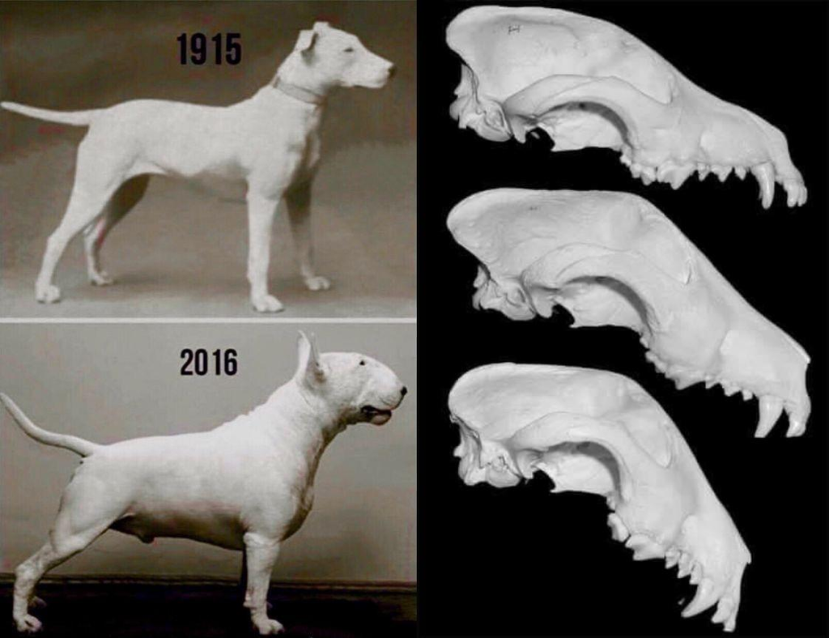

[Reddit/Damnthatsinteresting](https://www.reddit.com/r/Damnthatsinteresting/comments/1ba51ka/the_skeletal_results_of_selective_breeding_over/?tl=pt-br)

# Equilíbrio de Wright

## Equilíbrio de Wright

Em uma população infinitamente grande que não sofre pressão das forças evolutivas e que se reproduz tanto por cruzamentos aleatórios quanto por autofecundações $\left(F \neq 0\right)$, os cruzamentos endogâmicos alteram as frequências genotípicas, sem afetar as frequências alélicas.

$$\uparrow F \quad \uparrow f\left(\mbox{Homozigotos}\right)$$

## Equilíbrio de Wright

- O EW pode ser utilizado para separar as causas dos desvios do EHW:
  - Fatores evolutivos (mutação, seleção, deriva ou migração)
  - Fatores reprodutivos (autofecundação e/ou cruzamento entre parentes)
  - Caso não se ajuste ao EHW mas se ajuste ao EW, o desvio é devido à fatores reprodutivos
  - Índice de fixação intrapopulacional $\left(F_{IS}\right)$: redução na heterozigosidade em uma população devido a fatores reprodutivos

## Equilíbrio de Wright

| Genótipo | Frequências genotípicas esperadas |
| --- | --- |
| $AA$ | $D = p^2 \color{red}{+ Fpq}$ |
| $Aa$ | $H = 2pq \times \color{red}{(1-F)}$ |
| $aa$ | $R = q^2 \color{red}{+ Fpq}$ |

$$\begin{gather}
p = D + \frac{1}{2}H = p^2 + Fpq + \frac{2pq(1-F)}{2} = p \\
q = R + \frac{1}{2}H = q^2 + Fpq + \frac{2pq(1-F)}{2} = q
\end{gather}$$

## Equilíbrio de Wright

| Genótipo | Frequências genotípicas esperadas |
| --- | --- |
| $AA$ | $D = p^2 \color{red}{+ Fpq}$ |
| $Aa$ | $H = 2pq \color{red}{\times (1-F)}$ |
| $aa$ | $R = q^2 \color{red}{+ Fpq}$ |

Estimativas de $F$:

- Geração atual

$$F = \frac{4DR - H^2}{4DR - H^2 + 2H}$$

- Após $n$ autofecundações

$$F_n = \frac{1}{2}(1+F_{n-1})$$

## Equilíbrio de Wright

| Genótipo | Frequências genotípicas esperadas |
| --- | --- |
| $AA$ | $D = p^2 \color{red}{+ Fpq}$ |
| $Aa$ | $H = 2pq \color{red}{\times (1-F)}$ |
| $aa$ | $R = q^2 \color{red}{+ Fpq}$ |

- Frequência de heterozigotos após $n$ autofecundações

$$H_n = H_0 \times \left(\frac{1}{2}\right)^n$$

## Equilíbrio de Wright

- Geração S<sub>0</sub>
  - *S* vem de *selfing*, que significa autofecundação
  - S<sub>0</sub> $\to$ sem autofecundação
  - $F = 0$

| Genótipo | Frequências genotípicas esperadas |
| --- | --- |
| $AA$ | $D = p^2+ 0pq = p^2$ |
| $Aa$ | $H = 2pq (1-0) = 2pq$ |
| $aa$ | $R = q^2 + 0pq = q^2$ |

## Equilíbrio de Wright

- Geração S<sub>1</sub>
  - S<sub>1</sub> $\to$ 1 autofecundação
  - $F = \frac{1}{2}(1+0) = \frac{1}{2}$

| Genótipo | Frequências genotípicas esperadas |
| --- | --- |
| $AA$ | $D = p^2+ \frac{1}{2}pq$ |
| $Aa$ | $H = 2pq (1-\frac{1}{2})$ |
| $aa$ | $R = q^2 + \frac{1}{2}pq$ |

## Equilíbrio de Wright

- Geração S<sub>2</sub>
  - S<sub>2</sub> $\to$ 2 autofecundações
  - $F = \frac{1}{2}(1+\frac{1}{2}) = \frac{3}{4}$

| Genótipo | Frequências genotípicas esperadas |
| --- | --- |
| $AA$ | $D = p^2+ \frac{3}{4}pq$ |
| $Aa$ | $H = 2pq (1-\frac{3}{4})$ |
| $aa$ | $R = q^2 + \frac{3}{4}pq$ |

E as frequências alélicas?

## Equilíbrio de Wright

$$\begin{matrix}
\mathbf{\mbox{Autogamia}} & & \mathbf{\mbox{Alogamia}} \\
AA \times aa & & AA \times aa \\
\downarrow & & \downarrow \\
Aa & & Aa \\
\downarrow \otimes & & \downarrow \\
\frac{1}{4} AA, \frac{1}{2} Aa, \frac{1}{4} aa & & \frac{1}{4} AA, \frac{1}{2} Aa, \frac{1}{4} aa \\
\downarrow \otimes & & \downarrow \\
\frac{3}{8} AA, \frac{2}{8} Aa, \frac{3}{8} aa & & \frac{1}{4} AA, \frac{1}{2} Aa, \frac{1}{4} aa\\
\downarrow \otimes & & \downarrow \\
\frac{7}{16} AA, \frac{2}{16} Aa, \frac{7}{16} aa & & \frac{1}{4} AA, \frac{1}{2} Aa, \frac{1}{4} aa\\
\downarrow \otimes & & \downarrow \\
\vdots & & \vdots \\
\downarrow \otimes & & \downarrow \\
\frac{1}{2} AA, \frac{1}{2} aa & & \frac{1}{4} AA, \frac{1}{2} Aa, \frac{1}{4} aa\\
\end{matrix}$$

# Índice de fixação

## Índice de fixação

**Diagnóstico sobre a fuga do EHW relacionada à endogamia**

$$F_{IS} = 1 - \frac{H_{obs}}{H_{esp}} = 1 - \frac{H}{2pq}$$

- $H_{obs} \rightarrow$ Frequência genotípica de heterozigotos observada
- $H_{esp} \rightarrow$ Frequência genotípica de heterozigotos esperada em EHW

## Índice de fixação

$$F_{IS} = 1 - \frac{H_{obs}}{H_{esp}} = 1 - \frac{H}{2pq}$$

- $-1 \leq F_{IS} \leq 1$
  - $F_{IS} > 0 \rightarrow$ fuga do EHW devido à endogamia na população
  - $F_{IS} < 0 \rightarrow$ fuga do EHW por outro fator (ex.: seleção diferencial do heterozigoto)
  - $F_{IS} = 0 \rightarrow$ população em EHW

## Índice de fixação

- Taxa de autofecundação:

$$s = \frac{2F_{IS}}{1+F_{IS}}$$

- Taxa de cruzamento:

$$t = 1 - s$$

- Mecanismos de (des)favorecimento da endogamia
- Relação com $F_{IS}$:

$$F_{IS} = \frac{s}{2-s}$$

$$F_{IS} = \frac{1-t}{1+t}$$

# Apanhado geral

## Vimos hoje

A endogamia é a união de cópias de um mesmo alelo ancestral. Na maioria das populações de plantas e animais, a endogamia ocasiona uma perda de vigor chamada **depressão endogâmica**, relacionada com a união de alelos deletérios. Uma forma de mensurar a endogamia na população é calculando o coeficiente de endogamia $(F)$

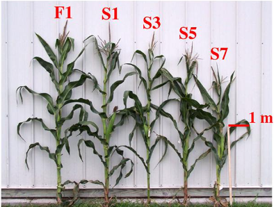

[Yao et al. (2020)](https://www.frontiersin.org/journals/genetics/articles/10.3389/fgene.2020.564928/full)

## Vimos hoje

Segundo o Equilíbrio de Wright, as frequências alélicas não mudam através das gerações, ainda que $F \neq 0$, supondo que se trata de uma população grande e sob ausência de processos dispersivos e sistemáticos de modificação de frequências alélicas

| Genótipo | Frequências genotípicas esperadas |
| --- | --- |
| $AA$ | $D = p^2 \color{red}{+ Fpq}$ |
| $Aa$ | $H = 2pq \times \color{red}{(1-F)}$ |
| $aa$ | $R = q^2 \color{red}{+ Fpq}$ |

$$F = \frac{4DR - H^2}{4DR - H^2 + 2H}$$

$$F_n = \frac{1}{2}(1+F_{n-1})$$

## Vimos hoje

O índice de fixação ou coeficiente de endogamia intrapopulacional $\left(F_{IS}\right)$ auxilia na determinação das causas da fuga do EHW. Relacionados à este índice estão as taxas relativas de autofecundação $(s)$ e cruzamento na população $(t)$

$$s = \frac{2F_{IS}}{1+F_{IS}}$$

$$t = 1 - s$$

$$F_{IS} = \frac{s}{2-s}$$

$$F_{IS} = \frac{1-t}{1+t}$$

## Para fixação

- Uma população em EHW possui 20% $AA$, 50% $Aa$ e 30% $aa$. Pergunta-se:
  - Quais as frequências alélicas na população $S_0$?
  - Qual a frequência de heterozigotos após três gerações de autofecundação?
  - Qual o índice de fixação nesta geração?
  - Qual conclusão pode ser tirada a partir do valor do índice?
- Quais os efeitos da endogamia sobre uma população de plantas alógamas?
- **Duas populações possuem taxas relativas de autofecundação diferentes. A primeira possui $s = 50\%$, e a segunda, $s = 98\%$. Qual sua conclusão a respeito do decaimento da heterozigosidade nas duas populações?**

## Material de apoio

- GRIFFITHS, A. J. F., WESSLER, S. R., CARROLL, S. B., & DOEBLEY, J. (2016). Capítulo 18: Genética de Populações. Introdução à Genética.
- RAMALHO, M. A. P., SANTOS, J. B., & PINTO, C. A. B. P. (2004). Capítulo 13: Genética de Populações. Genética Na Agropecuária.
- SNUSTAD, D. P., & SIMMONS, M. J. (2010). Capítulo 20: Genética de populações. Fundamentos de Genética.
- [Sobre a família Whittaker](https://www.youtube.com/watch?v=WnzMPF6vFJk)
- [Sobre os Habsburgo](https://www.palaces-of-europe.com/spanish-habsburg-family-tree.html#gallery%5BpageGallery%5D/0/)
- [Raças endogâmicas de cães](https://www.instituteofcaninebiology.org/blog/inbreeding-of-purebred-dogs-determined-from-dna)